# Recitation 4: Empirical Exercise 1 Help

## Outline

- Go through 3a
- Simple Regressions, stargazer
- Group Q&A

## Homework

3. Since the previous dataset only had capacity for 10 years, the next step is to download data from EIA Form 860 to build capacity for a period as long as the one for emissions
1. Follow the steps covered during recitation to build the total capacity of source for each year.

## Imports

```r
library(data.table)
library(readxl)
library(tidyverse)
```

## Download and unzip file

```r
# This dataset is no longer the early release version!
url <- "https://www.eia.gov/electricity/data/eia860/xls/eia8602019.zip"

# I want a variable for the name of my data folder
data_folder <-  "data"
# Create the folde if it doesn't exist
dir.create(file.path(".", data_folder), showWarnings = T)
# Get the path of the file when it is stored on disk
fname <- file.path(data_folder, basename(url))
fname
```

```
## [1] "data/eia8602019.zip"
```

```r
# If the file doesn't exist already, download from the URL (the web) to the path (your computer's folder called data, relative to your working directory)
if (!file.exists(fname)){
  download.file(url, fname)
}
# Unzip the folder
unzip(fname, exdir = data_folder)
```

## Look and examine the data

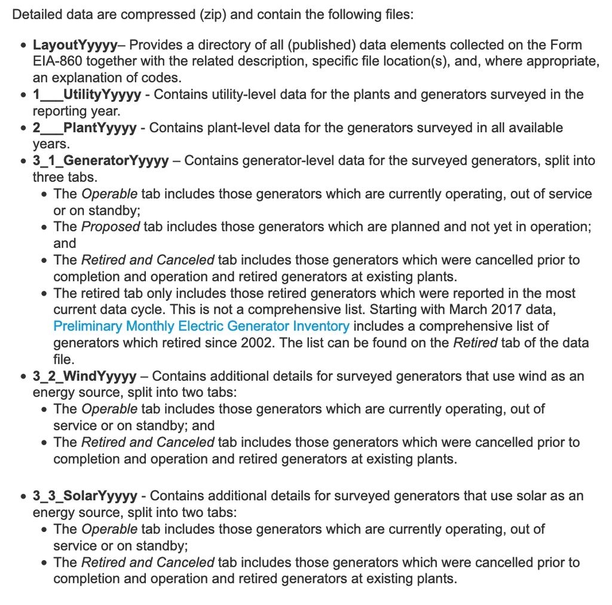

- What is the difference between 1, 2 and 3?

> the relevant data is in 3
- What is the difference between 3.1 and 3.2…

> “Additional Details” are in 3_2+, these we don’t need because the capacity, technology, and the operating and retirement years are in 3_1.
- Look at the data we want, is it sufficient to answer the question?

> …build capacity for a period as long as the one for emissions

## Assumption

We don’t need any more data. Assume:

- All power plants in ‘Operable’ are still ‘active’ and have been active since “Operating Year”
- All power plants in ‘Retired and Cancelled’ were ‘active’ from “Operating Year” until “Retirement Year”, and that this dataset is exhaustive.
- Power plant capacity in any given year is the total capacity of ‘active’ plants.

## 2 methods

- Have a column with active status…
- Keep a running tally for each fuel and year.
- What is the minimum dataset we need for each method?

## High-level algorithm for the running tally method

My ideal dataset has a cumulative capacity for each technology-year pair.

1. For all those power plants are operable, we assume they are active up until the current year, so they never go offline.
2. For all those power plants in ‘Retired and Cancelled’, we assume they are active between their operating and retirement years; if there’s no data, we just assume they are cancelled and never operated.
3. Get the sum of Power Plant Capacity that came online in each year from the Operating Year column - ‘additions’ - by technology.
4. Get the sum of Power Plant Capacity that was retired/came offline from the Retirement Year column - ‘subtractions’ - in each year by technology.
5. The ‘net capacity change’ for each technology-year pair is additions less subtractions.
6. Running a cumulative sum over the years by technology will give me the total capacity by technology in each year.